# **Classification Exercise**

The dataset contains records of males in a heart-disease high-risk region of the Western Cape, South Africa. There are roughly two controls per case of CHD. Many of the CHD positive men have undergone blood pressure reduction treatment and other programs to reduce their risk factors after their CHD event. In some cases the measurements were made after these treatments. These data are taken from a larger dataset, described in Rousseauw et al. (1983), South African Medical Journal. It is a tab separated file (csv) and contains the following columns

- sbp - Systolic blood pressure
- tobacco - Cumulative tobacco (kg)
- ldl - Low density lipoprotein cholesterol
- adiposity
- famhist - Family history of heart disease (Present, Absent)
- typea - type-A behavior
- obesity
- alcohol - Current alcohol consumption
- age - Age at onset
- chd - Response, coronary heart disease

The chd = 1 and chd = 0 will be referred as chd and no chd cases, respectively.

1. Find out the number cases available in the dataset for chd and no chd. Is it an imbalanced dataset for classification modelling? Plot the findings using a bar plot, where x is chd or no chd and

y gives the count of samples in each group.

```python
import pandas as pd
pd.set_option('display.max_columns', 100)

# Numpy for numerical computing
import numpy as np

# Matplotlib for visualization
from matplotlib import pyplot as plt
# display plots in the notebook
%matplotlib inline

# Seaborn for easier visualization
import seaborn as sns
sns.set_style('darkgrid')

# display Python object in all frontends
from IPython.display import display

# store elements as dictionary keys and their counts as dictionary values
from collections import Counter
```

```python
import pandas as pd
ch=pd.read_csv("SAheart.csv")
ch.columns
```

```
Index(['sbp', 'tobacco', 'ldl', 'adiposity', 'famhist', 'typea', 'obesity',
       'alcohol', 'age', 'chd'],
      dtype='object')
```

```python
ch.famhist.unique()
```

```
array(['Present', 'Absent'], dtype=object)
```

```python
import warnings
warnings.filterwarnings ('ignore')
ch.chd.unique()
ch.chd[ch.chd== 'Si'] = 1
ch.chd[ch.chd== 'No'] = 0
ch.famhist[ch.famhist== 'Present'] = 1
ch.famhist[ch.famhist== 'Absent'] = 0
ch = ch.astype(str).astype(float)
ch.head()
```

|  | sbp | tobacco | ldl | adiposity | famhist | typea | obesity | alcohol | age | chd |
| --- | --- | --- | --- | --- | --- | --- | --- | --- | --- | --- |
| 0 | 160.0 | 12.00 | 5.73 | 23.11 | 1.0 | 49.0 | 25.30 | 97.20 | 52.0 | 1.0 |
| 1 | 144.0 | 0.01 | 4.41 | 28.61 | 0.0 | 55.0 | 28.87 | 2.06 | 63.0 | 1.0 |
| 2 | 118.0 | 0.08 | 3.48 | 32.28 | 1.0 | 52.0 | 29.14 | 3.81 | 46.0 | 0.0 |
| 3 | 170.0 | 7.50 | 6.41 | 38.03 | 1.0 | 51.0 | 31.99 | 24.26 | 58.0 | 1.0 |
| 4 | 134.0 | 13.60 | 3.50 | 27.78 | 1.0 | 60.0 | 25.99 | 57.34 | 49.0 | 1.0 |

```python
ch.shape
```

```
(462, 10)
```

```python
ch.chd.value_counts()
```

```
chd
0.0    302
1.0    160
Name: count, dtype: int64
```

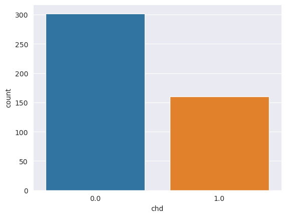

```python
# Bar plot for 'gender'
sns.countplot(x='chd', data=ch)
plt.show()
```

2. To create a balanced dataset, do upsampling of chd cases to be same as number of no chd cases. For

upsampling, use resampling with replacement technique.

```python
## Importing resample from *sklearn.utils* package.
from sklearn.utils import resample

chd_no = ch[ch.chd == 0]
chd_yes = ch[ch.chd == 1]
##Upsample the yes- cases.
ch_minority_upsampled = resample(chd_yes,
replace=True,
n_samples=302)

# Combine majority class with upsampled minority class
new_ch = pd.concat([chd_no, ch_minority_upsampled])
new_ch.shape

from sklearn.utils import shuffle
balanced_ch = shuffle(new_ch)
```

3. Maintain two datasets - imbalanced dataset (original one) and balanced dataset - using the upsampling approach. Split each of the datasets into 80:20 splits for creating training and test sets.

```python
Y = ch['chd'].astype('float')
ch.drop(columns='chd', inplace=True)

Y_balanced = balanced_ch['chd'].astype('float')
balanced_ch.drop(columns='chd', inplace=True)
```

```python
from sklearn.model_selection import train_test_split
train_X_inbalanced, test_X_inbalanced, train_y_inbalanced, test_y_inbalanced = train_test_split(ch,Y,test_size=0.2, random_state=42)
```

```python
from sklearn.model_selection import train_test_split
train_X_balanced, test_X_balanced, train_y_balanced, test_y_balanced = train_test_split(balanced_ch,Y_balanced,test_size=0.2, random_state=42)
```

4. Build a logistic regression model using both the imbalanced and balanced datasets and compare results. Use K-fold cross-validation (k = 5) and ROC AUC score for comparing the model

performance.

```python
import warnings
warnings.filterwarnings ('ignore')
from sklearn.linear_model import LogisticRegression
## Initializing the model
logit = LogisticRegression()
## Fitting the model with X and Y values of the dataset
logit.fit( train_X_inbalanced, train_y_inbalanced)

pred_y_inbalanced = logit.predict(test_X_inbalanced)
```

```python
from sklearn.linear_model import LogisticRegression
## Initializing the model
logit = LogisticRegression()
## Fitting the model with X and Y values of the dataset
logit.fit( train_X_balanced, train_y_balanced)

pred_y_balanced = logit.predict(test_X_balanced)
```

[figure not shown]

```python
# Importing the metrics
import seaborn as sn
from sklearn import metrics
def draw_cm( actual, predicted ):
    classes = [1,0]
    cm = metrics.confusion_matrix( actual, predicted )
    sn.heatmap(cm, annot=True, fmt='.2f',xticklabels = ["chd", "no chd"] ,yticklabels = ["chd", "no chd"] )
    plt.ylabel('True label')
    plt.xlabel('Predicted label')
    plt.show()
cm_inbalanced = draw_cm( test_y_inbalanced, pred_y_inbalanced )
cm_inbalanced
```

[figure not shown]

```python
# Importing the metrics
import seaborn as sn
from sklearn import metrics
def draw_cm( actual, predicted ):
    classes = [1,0]
    cm = metrics.confusion_matrix( actual, predicted )
    sn.heatmap(cm, annot=True, fmt='.2f',xticklabels = ["chd", "no chd"] ,yticklabels = ["chd", "no chd"] )
    plt.ylabel('True label')
    plt.xlabel('Predicted label')
    plt.show()
cm_balanced = draw_cm( test_y_balanced, pred_y_balanced )
cm_balanced
```

```python
print( metrics.classification_report( test_y_inbalanced, pred_y_inbalanced ) )
```

```
              precision    recall  f1-score   support

         0.0       0.74      0.86      0.80        59
         1.0       0.67      0.47      0.55        34

    accuracy                           0.72        93
   macro avg       0.70      0.67      0.67        93
weighted avg       0.71      0.72      0.71        93
```

```python
print( metrics.classification_report( test_y_balanced, pred_y_balanced ) )
```

```
              precision    recall  f1-score   support

         0.0       0.71      0.68      0.69        60
         1.0       0.70      0.72      0.71        61

    accuracy                           0.70       121
   macro avg       0.70      0.70      0.70       121
weighted avg       0.70      0.70      0.70       121
```

```python
## Predicting the probability values for test cases
predict_proba_df = pd.DataFrame( logit.predict_proba( test_X_inbalanced ) )
predict_proba_df.head()
```

|  | 0 | 1 |
| --- | --- | --- |
| 0 | 0.553737 | 0.446263 |
| 1 | 0.507811 | 0.492189 |
| 2 | 0.113133 | 0.886867 |
| 3 | 0.331209 | 0.668791 |
| 4 | 0.561641 | 0.438359 |

```python
## Predicting the probability values for test cases
predict_proba_balanced = pd.DataFrame( logit.predict_proba( test_X_balanced ) )
predict_proba_balanced.head()
```

|  | 0 | 1 |
| --- | --- | --- |
| 0 | 0.668712 | 0.331288 |
| 1 | 0.542989 | 0.457011 |
| 2 | 0.299152 | 0.700848 |
| 3 | 0.625994 | 0.374006 |
| 4 | 0.678724 | 0.321276 |

```python
## Initializing the DataFrame with actual class lables
test_results_df = pd.DataFrame( { 'actual': test_y_inbalanced } )
test_results_df = test_results_df.reset_index()
## Assigning the probability values for class label 1
test_results_df['chd_1'] = predict_proba_df.iloc[:,1:2]
```

```python
## Initializing the DataFrame with actual class lables
test_results_balanced = pd.DataFrame( { 'actual': test_y_balanced } )
test_results_balanced = test_results_balanced.reset_index()
## Assigning the probability values for class label 1
test_results_balanced['chd_1'] = predict_proba_balanced.iloc[:,1:2]
```

```python
test_results_df.head(5)
```

|  | index | actual | chd_1 |
| --- | --- | --- | --- |
| 0 | 225 | 0.0 | 0.446263 |
| 1 | 30 | 1.0 | 0.492189 |
| 2 | 39 | 1.0 | 0.886867 |
| 3 | 222 | 0.0 | 0.668791 |
| 4 | 124 | 0.0 | 0.438359 |

```python
test_results_balanced.head(5)
```

|  | index | actual | chd_1 |
| --- | --- | --- | --- |
| 0 | 75 | 0.0 | 0.331288 |
| 1 | 47 | 1.0 | 0.457011 |
| 2 | 14 | 0.0 | 0.700848 |
| 3 | 457 | 0.0 | 0.374006 |
| 4 | 261 | 0.0 | 0.321276 |

```python
auc_score = metrics.roc_auc_score( test_results_df.actual, test_results_df.chd_1)
round( float( auc_score ), 2 )
```

```
0.79
```

```python
auc_score_balanced = metrics.roc_auc_score( test_results_balanced.actual, test_results_balanced.chd_1)
round( float( auc_score_balanced ), 2 )
```

```
0.78
```

```python
def draw_roc_curve( model, test_X_inbalanced, test_y_inbalanced ):
    test_results_df = pd.DataFrame( { 'actual': test_y_inbalanced } )
    test_results_df = test_results_df.reset_index()
    predict_proba_df = pd.DataFrame( model.predict_proba( test_X_inbalanced ) )
    test_results_df['chd_1'] = predict_proba_df.iloc[:,1:2]
    fpr, tpr, thresholds = metrics.roc_curve( test_results_df.actual,test_results_df.chd_1,drop_intermediate = False )
    ## Getting the roc auc score by invoking metrics.roc_auc_score method
    auc_score = metrics.roc_auc_score( test_results_df.actual, test_results_df.chd_1 )
 ## Setting the size of the plot
    plt.figure(figsize=(8, 6))
 ## plotting the actual fpr and tpr values
    plt.plot( fpr, tpr, label='ROC curve (area = %0.2f)' % auc_score )
 ## plotting th diagnoal line from (0,1)
    plt.plot([0, 1], [0, 1], 'k--')
    plt.xlim([0.0, 1.0])
    plt.ylim([0.0, 1.05])
 ## Setting labels and titles
    plt.xlabel('False Positive Rate or [1 - True Negative Rate]')
    plt.ylabel('True Positive Rate')
    plt.title('Receiver operating characteristic example')
    plt.legend(loc="lower right")
    plt.show()
    return auc_score, fpr, tpr, thresholds
```

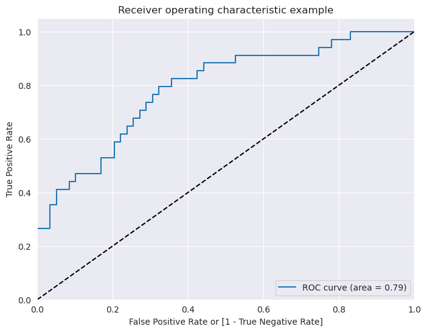

```python
## Invoking draw_roc_curve with the logistic regresson model
_, _, _, _ = draw_roc_curve( logit, test_X_inbalanced, test_y_inbalanced )
```

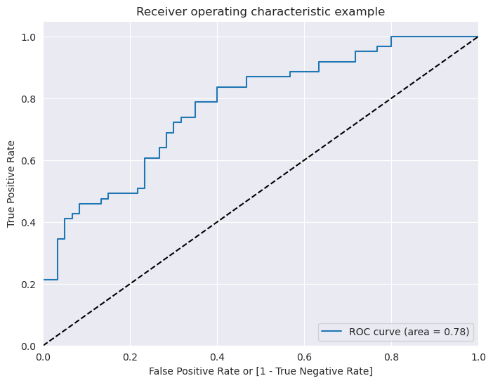

```python
def draw_roc_curve_balanced( model, test_X_balanced, test_y_balanced ):
    test_results_df = pd.DataFrame( { 'actual': test_y_balanced } )
    test_results_df = test_results_df.reset_index()
    predict_proba_df = pd.DataFrame( model.predict_proba( test_X_balanced ) )
    test_results_df['chd_1'] = predict_proba_df.iloc[:,1:2]
    fpr, tpr, thresholds = metrics.roc_curve( test_results_df.actual,test_results_df.chd_1,drop_intermediate = False )
    ## Getting the roc auc score by invoking metrics.roc_auc_score method
    auc_score = metrics.roc_auc_score( test_results_df.actual, test_results_df.chd_1 )
 ## Setting the size of the plot
    plt.figure(figsize=(8, 6))
 ## plotting the actual fpr and tpr values
    plt.plot( fpr, tpr, label='ROC curve (area = %0.2f)' % auc_score )
 ## plotting th diagnoal line from (0,1)
    plt.plot([0, 1], [0, 1], 'k--')
    plt.xlim([0.0, 1.0])
    plt.ylim([0.0, 1.05])
 ## Setting labels and titles
    plt.xlabel('False Positive Rate or [1 - True Negative Rate]')
    plt.ylabel('True Positive Rate')
    plt.title('Receiver operating characteristic example')
    plt.legend(loc="lower right")
    plt.show()
    return auc_score, fpr, tpr, thresholds

## Invoking draw_roc_curve with the logistic regresson model
_, _, _, _ = draw_roc_curve_balanced( logit, test_X_balanced, test_y_balanced)
```

5. Build a Random Forest model using balanced dataset. Use grid search mechanism to find the most

optimal values of the following parameters:

- n_estimators = [50, 100, 200, 500]
- max_depth = [3, 5, 7, 9]
- max_features = [0.1, 0.2, 0.3, 0.5]

Find the best model based on ROC_AUC score.

```python
from sklearn.ensemble import RandomForestClassifier
radm_clf = RandomForestClassifier(max_depth=10, n_estimators=10)
radm_clf.fit(train_X_balanced, train_y_balanced)
```

```
RandomForestClassifier(max_depth=10, n_estimators=10)
```

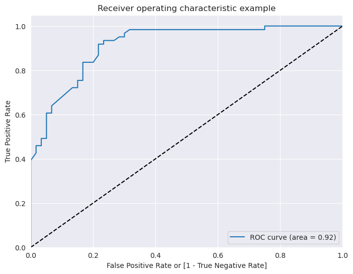

```python
_, _, _, _ = draw_roc_curve_balanced(radm_clf, test_X_balanced, test_y_balanced)
```

```python
from sklearn.model_selection import GridSearchCV
from sklearn.ensemble import RandomForestClassifier
rf = RandomForestClassifier(random_state=42)
param_grid = {
    'n_estimators': [50, 100, 200, 500],
    'max_depth': [3, 5, 7, 9],
    'max_features': [0.1, 0.2, 0.3, 0.5]
}
grid_search = GridSearchCV(estimator=rf, param_grid=param_grid,
                           cv=5, n_jobs=-1, verbose=2, scoring='accuracy')
grid_search.fit(train_X_balanced, train_y_balanced)
```

```
Fitting 5 folds for each of 64 candidates, totalling 320 fits
```

```
GridSearchCV(cv=5, estimator=RandomForestClassifier(random_state=42), n_jobs=-1,
             param_grid={'max_depth': [3, 5, 7, 9],
                         'max_features': [0.1, 0.2, 0.3, 0.5],
                         'n_estimators': [50, 100, 200, 500]},
             scoring='accuracy', verbose=2)
```

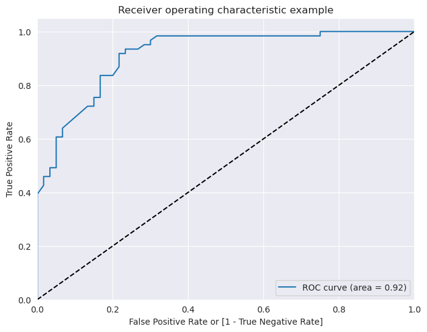

```python
_, _, _, _ = draw_roc_curve_balanced(radm_clf, test_X_balanced, test_y_balanced)
```

Interpret the rules generated by the decision tree. Explain how these rules can be used in the real world.

```python
from sklearn.tree import DecisionTreeClassifier
decisiontree = DecisionTreeClassifier(max_depth=4, criterion="entropy", random_state=42)
decisiontree.fit(train_X_balanced, train_y_balanced)
```

```
DecisionTreeClassifier(criterion='entropy', max_depth=4, random_state=42)
```

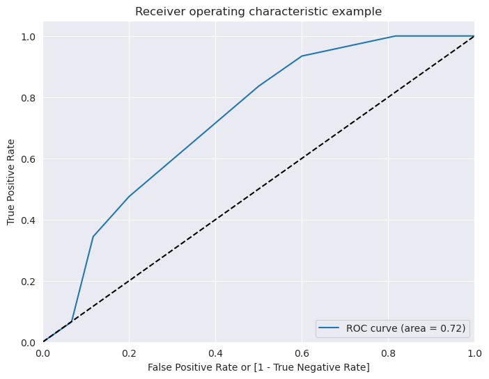

[output not shown]

[output cut: 265 more lines]

[output not shown]

```python
_, _, _, _ = draw_roc_curve_balanced(decisiontree, test_X_balanced, test_y_balanced)
```

```python
from sklearn.model_selection import GridSearchCV
from sklearn.tree import DecisionTreeClassifier
params = {'max_depth': [4],
          'criterion': ["entropy"]
         }
grid_search_cv = GridSearchCV(DecisionTreeClassifier(random_state=42), params, cv=3)
grid_search_cv.fit(train_X_balanced, train_y_balanced)
```

```
GridSearchCV(cv=3, estimator=DecisionTreeClassifier(random_state=42),
             param_grid={'criterion': ['entropy'], 'max_depth': [4]})
```

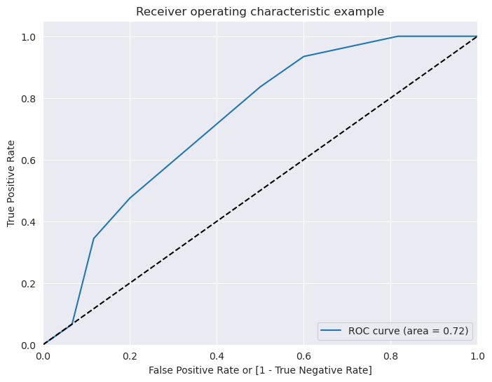

```python
_, _, _, _ = draw_roc_curve_balanced(grid_search_cv, test_X_balanced, test_y_balanced)
```